# ENGSCI 211 – 2020 S1 Test 2 – Section B: Data Analysis

# Question 3 (10 marks)

Question 3 requires you to conduct an analysis in RStudio or R on the dataset described below. The dataset is available on Canvas as the file `bus25Data.txt`.

It is claimed that bus services in Auckland are busier on Mondays than on Fridays. To verify this claim, data was collected on the number of people that board the Dominion Road bus services (25B and 25L) on Mondays and Fridays during University of Auckland teaching weeks in 2019. In 2019, the University was open for teaching on 23 Mondays and 24 Fridays.

Estimate the difference in the average number of boardings between Mondays and Fridays, and hence comment on whether the collected data support the claim.

The file `bus25Data.txt` contains the following variables:

`Boardings`: Number of recorded boardings on the Dominion Road bus services 25B and 25L.  
`Weekday`: Weekday of observation, either `Monday` or `Friday`.

Source: Auckland Transport.

**Q3(a) (2 marks)**: Why is this **NOT** an example of a paired analysis? What additional information is required to conduct a paired analysis on this dataset?

We are not measuring the same people on Monday and Friday taking the bus, if it was, then this could undergo paired analysis.

**Q3(b) (2 marks)**: Conduct the appropriate analysis in R to answer the question. Your analysis should contain the following, similar to the Case Studies and Assignment:

- exploratory analysis
- checking modelling assumptions
- appropriate statistical inference, i.e. hypothesis tests and / or confidence intervals

You are not required to annotate your analysis.

If you are using R 4.0.0, you may need to explicitly make `Weekday` a `factor`. See Block 4 Slide 6 for an example of the command required.

```r
library(s20x)
bus.df = read.table("bus25Data.txt", header = TRUE)
head(bus.df)
```

```
##   Weekday Boardings
## 1  Friday     10934
## 2  Friday     11606
## 3  Friday     11451
## 4  Friday     11345
## 5  Friday     11395
## 6  Friday     10853
```

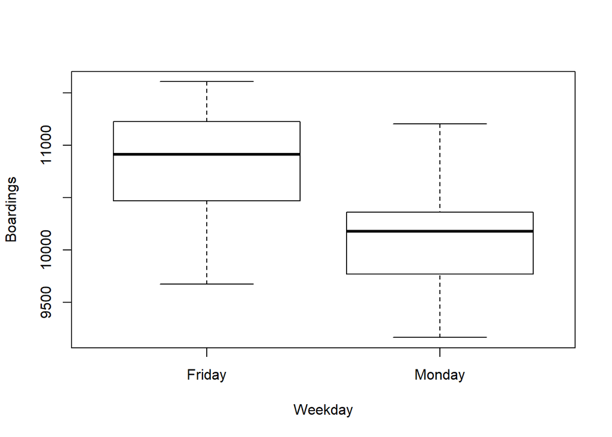

```r
boxplot(Boardings ~ Weekday, data = bus.df)
```

```r
bus.fit = lm(Boardings ~ Weekday, data = bus.df)
```

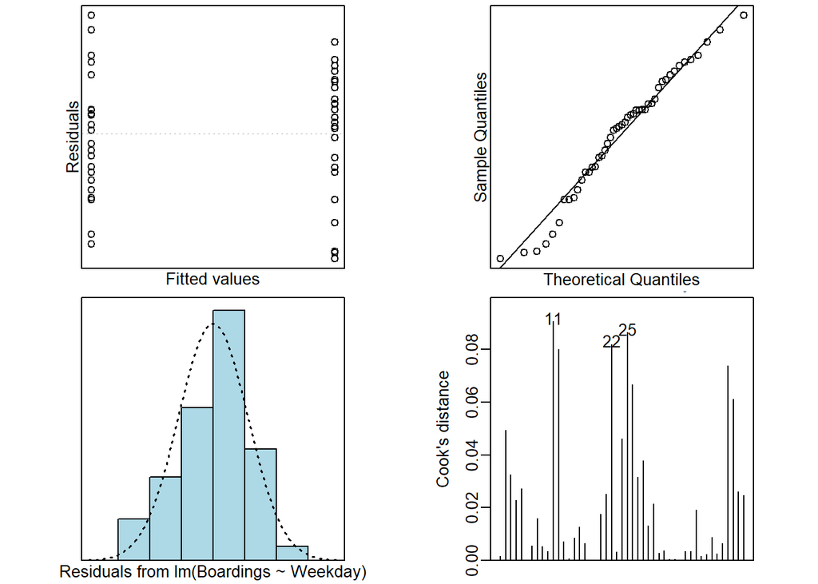

```r
modcheck(bus.fit)
```

```r
summary(bus.fit)
```

```
##
## Call:
## lm(formula = Boardings ~ Weekday, data = bus.df)
##
## Residuals:
##     Min      1Q  Median      3Q     Max
## -1112.0  -339.4    84.3   364.0  1061.3
##
## Coefficients:
##               Estimate Std. Error t value Pr(>|t|)
## (Intercept)    10785.0      113.6   94.96  < 2e-16 ***
## WeekdayMonday   -641.3      162.4   -3.95 0.000272 ***
## ---
## Signif. codes:  0 '***' 0.001 '**' 0.01 '*' 0.05 '.' 0.1 ' ' 1
##
## Residual standard error: 556.4 on 45 degrees of freedom
## Multiple R-squared:  0.2575, Adjusted R-squared:  0.241
## F-statistic:  15.6 on 1 and 45 DF,  p-value: 0.0002722
```

```r
multipleComp(bus.fit)
```

```
## Estimate  Tukey.L  Tukey.U  Tukey.p
## 641.3460 314.3441 968.3479   0.0003
```

**Q3(c) (3 marks)**: Comment on the exploratory analysis you conducted on this dataset.

This means that generally, there are more boardings on Friday than Monday.

**Q3(d) (3 marks)**: Write a brief **Executive Summary** explaining the findings of the analysis that you have conducted.

In a comparison of Mondays and Fridays, the boardings per day onto Dominion Road bus services (25B and 25L) was recorded.

We estimate that between 314 and 969 more people board on a Friday than a Monday. This means that the collected data contradicts the claim made that more people board on Mondays than Fridays.

Our model explained 25% of the variation in the data.

# Question 4 (10 marks)

**Q4(a) (2 marks)**: Comment on the validity of the following claim:

> For any statistical analyses, a 90% confidence interval will provide a more accurate estimate of the true population mean than the corresponding 95% confidence interval.

The 95% confidence interval means that when a sample is selected, there is a 95% chance of the true population mean being represented within the sample selected. If we lower this to 90% then it will have a smaller difference in the intervals, as it only needs to represent the true population mean 90% of the time. Just because the difference in intervals is smaller does not mean it is more accurate. And since we are attempting to get intervals for which the the true population mean is more likely to lie in, the 95% confidence interval is actually a more accurate measure than the 90%.

The equality of variance assumption is not satisfied, as we see a fan effect of the residuals.

**Q4(c) (1 mark)**: With reference to appropriate diagnostic plot(s), comment on whether the **Normality assumption** is satisfied by the model `hills.fit2`.

The majority of the points lie on the line of the Q-Q plot, meaning that the data is approximately normally distributed, so we can conclude that the normality assumption is satisfied.

It was of interest to model the relationship between the map distance and the vertical elevation gained in the races.The climb increases in value with an exponential relationship relative to distance (miles)

We estimate that the average climb (total vertical elevation per race) increases between 10 and 21% for every mile run.

Our model explains 55% of the variation in the data.

**Q4(e) (2 marks)**: Give an appropriate estimate for the average total vertical elevation, for hill races with a map distance of 7 miles. State clearly whether your estimate relates to the mean or median.

Due to the nature of the transformation, our estimate relates to the median, not the mean. Our model also only explains 55% of the variation and therefore is likely not very suitable for doing such predictions.

We predict that the average total vertical elevation, for hill races with a map distance of 7 miles is between 1075 and 1586 feet.